# Gruppe 4 - Final

### Gruppenzusammensetzung: Alexander, Anke, Jasper, Nicholas

# Vorbereitung Umgebung (im Hintergrund)

# Daten einlesen

## Bereitgestellte Daten einlesen (im Hintergrund)

## Feiertagsdaten aus dem Netz holen (im Hintergrund)

## Daten zusammenfügen

```
## # A tibble: 10,899 x 11
##    Datum      Warengruppe Umsatz Wochentag  KielerWoche Bewoelkung Temperatur
##    <date>     <fct>        <dbl> <fct>            <dbl>      <dbl>      <dbl>
##  1 2013-07-01 Brot         149.  Montag              NA          6       17.8
##  2 2013-07-02 Brot         160.  Dienstag            NA          3       17.3
##  3 2013-07-03 Brot         112.  Mittwoch            NA          7       21.1
##  4 2013-07-04 Brot         169.  Donnerstag          NA          7       18.8
##  5 2013-07-05 Brot         171.  Freitag             NA          5       20.0
##  6 2013-07-06 Brot         175.  Samstag             NA          0       19.0
##  7 2013-07-07 Brot          92.6 Sonntag             NA          0       21.4
##  8 2013-07-08 Brot         136.  Montag              NA          0       22.7
##  9 2013-07-09 Brot         136.  Dienstag            NA          0       23.3
## 10 2013-07-10 Brot         135.  Mittwoch            NA          2       19.7
## # … with 10,889 more rows, and 4 more variables: Windgeschwindigkeit <dbl>,
## #   Wettercode <dbl>, Feiertage <chr>, istFeiertag <dbl>
```

# Datenaufbereitung

## Datenstruktur untersuchen

Data summary

| Name | dataset |
| --- | --- |
| Number of rows | 10899 |
| Number of columns | 11 |
| _______________________ |  |
| Column type frequency: |  |
| character | 1 |
| Date | 1 |
| factor | 2 |
| numeric | 7 |
| ________________________ |  |
| Group variables | None |

**Variable type: character**

| skim_variable | n_missing | complete_rate | min | max | empty | n_unique | whitespace |
| --- | --- | --- | --- | --- | --- | --- | --- |
| Feiertage | 10784 | 0.01 | 11 | 25 | 0 | 5 | 0 |

**Variable type: Date**

| skim_variable | n_missing | complete_rate | min | max | median | n_unique |
| --- | --- | --- | --- | --- | --- | --- |
| Datum | 0 | 1 | 2013-07-01 | 2019-06-06 | 2016-06-17 | 2121 |

**Variable type: factor**

| skim_variable | n_missing | complete_rate | ordered | n_unique | top_counts |
| --- | --- | --- | --- | --- | --- |
| Warengruppe | 0 | 1 | FALSE | 6 | Bro: 2121, Bro: 2121, Cro: 2121, Kuc: 2121 |
| Wochentag | 0 | 1 | FALSE | 7 | Son: 1570, Don: 1568, Sam: 1564, Die: 1562 |

**Variable type: numeric**

| skim_variable | n_missing | complete_rate | mean | sd | p0 | p25 | p50 | p75 | p100 | hist |
| --- | --- | --- | --- | --- | --- | --- | --- | --- | --- | --- |
| Umsatz | 0 | 1.00 | 206.66 | 142.81 | 7.05 | 97.53 | 163.30 | 280.81 | 1879.46 | ▇▁▁▁▁ |
| KielerWoche | 10676 | 0.02 | 1.00 | 0.00 | 1.00 | 1.00 | 1.00 | 1.00 | 1.00 | ▁▁▇▁▁ |
| Bewoelkung | 135 | 0.99 | 4.73 | 2.65 | 0.00 | 3.00 | 6.00 | 7.00 | 8.00 | ▃▂▂▅▇ |
| Temperatur | 81 | 0.99 | 11.82 | 7.15 | -8.47 | 6.11 | 11.26 | 17.62 | 32.67 | ▁▇▇▆▁ |
| Windgeschwindigkeit | 81 | 0.99 | 11.00 | 4.14 | 3.00 | 8.00 | 10.00 | 13.00 | 35.00 | ▇▇▂▁▁ |
| Wettercode | 2602 | 0.76 | 36.16 | 27.04 | 0.00 | 10.00 | 22.00 | 61.00 | 95.00 | ▆▃▁▇▁ |
| istFeiertag | 10784 | 0.01 | 1.00 | 0.00 | 1.00 | 1.00 | 1.00 | 1.00 | 1.00 | ▁▁▇▁▁ |

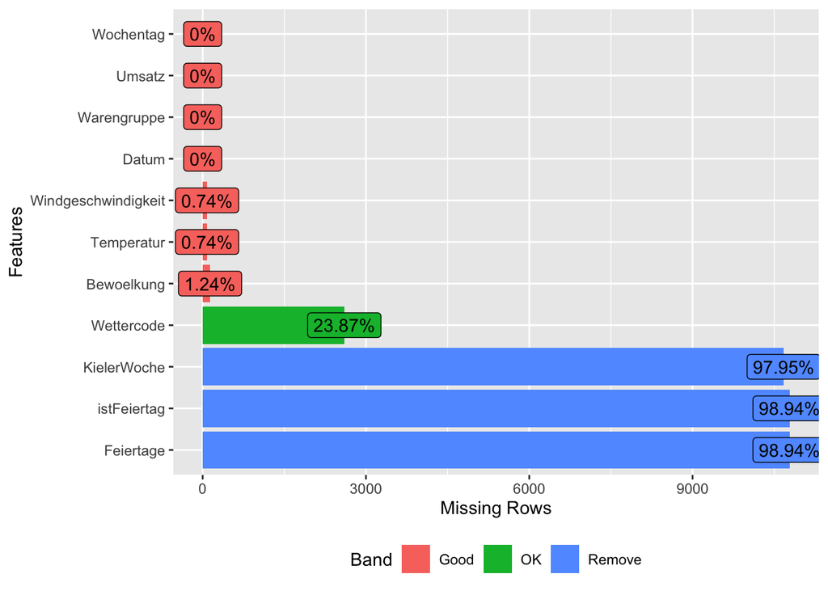

## Analyse der Ausreißer in den metrischen Variablen

- Temperatur: keine
- Bewoelkung: keine
- Windgeschwindigkeit: Ausreißer
- Umsatz: Ausreißer
- Umsatz nach Warengruppen: Ausreißer

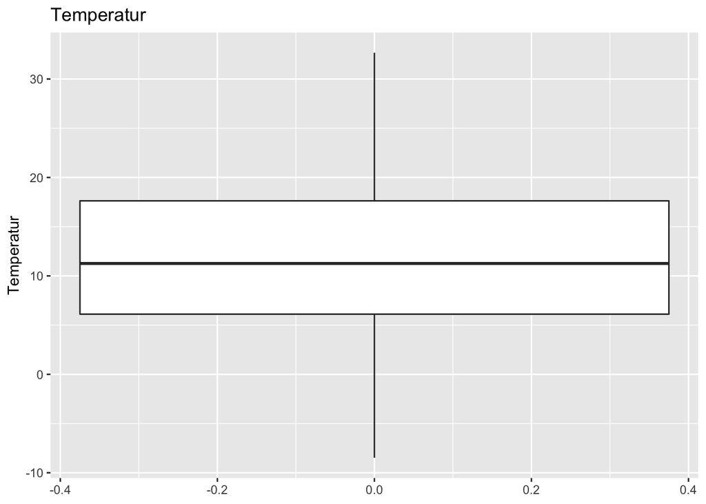

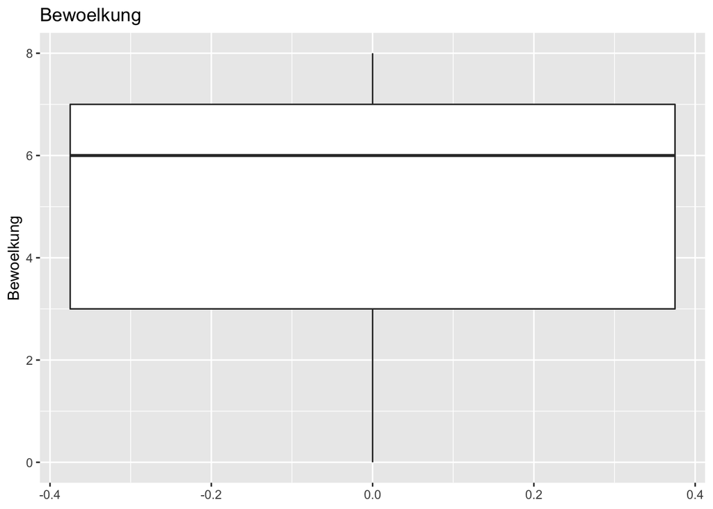

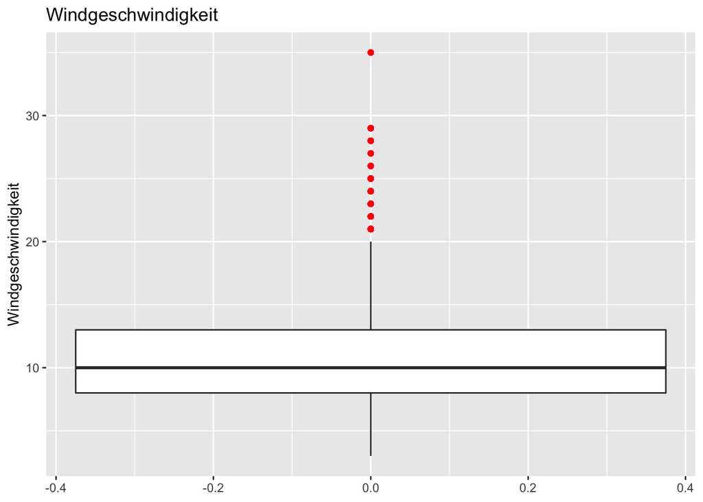

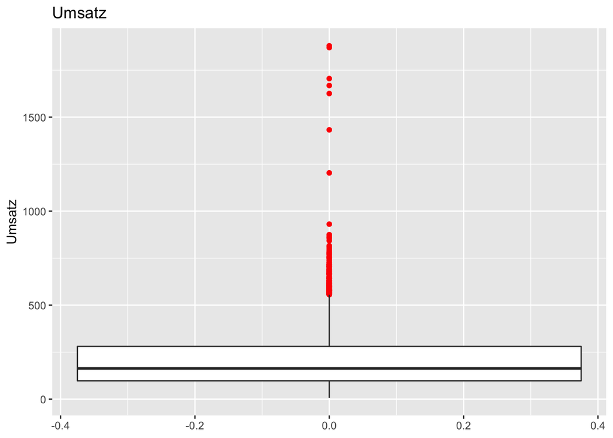

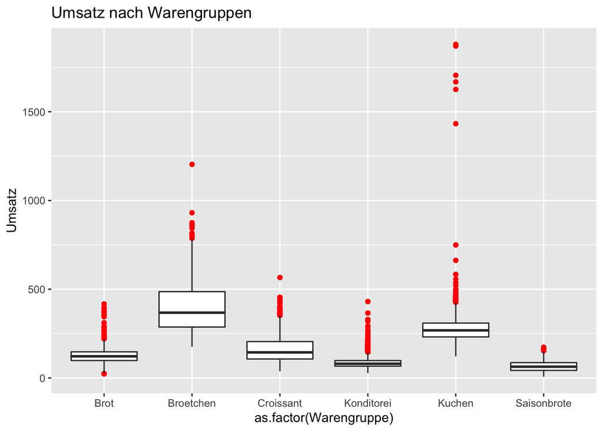

- Test auf Unterschiede der Mittelwerte im Umsatz per Warengruppen, um ggf. Warengruppen zusammenzufassen: nicht zu empfehlen, alle Unterschiede sig. von 0 verschieden

```
##   Tukey multiple comparisons of means
##     95% family-wise confidence level
##
## Fit: aov(formula = Umsatz ~ Warengruppe, data = dataset)
##
## $Warengruppe
##                              diff        lwr        upr     p adj
## Broetchen-Brot          274.47832  267.03128  281.92535 0.0000000
## Croissant-Brot           40.11876   32.67173   47.56580 0.0000000
## Konditorei-Brot         -36.80747  -44.30298  -29.31196 0.0000000
## Kuchen-Brot             153.79543  146.34840  161.24246 0.0000000
## Saisonbrote-Brot        -57.11407  -71.14025  -43.08790 0.0000000
## Croissant-Broetchen    -234.35955 -241.80659 -226.91252 0.0000000
## Konditorei-Broetchen   -311.28579 -318.78130 -303.79028 0.0000000
## Kuchen-Broetchen       -120.68289 -128.12992 -113.23586 0.0000000
## Saisonbrote-Broetchen  -331.59239 -345.61856 -317.56622 0.0000000
## Konditorei-Croissant    -76.92624  -84.42175  -69.43072 0.0000000
## Kuchen-Croissant        113.67666  106.22963  121.12370 0.0000000
## Saisonbrote-Croissant   -97.23284 -111.25901  -83.20667 0.0000000
## Kuchen-Konditorei       190.60290  183.10739  198.09841 0.0000000
## Saisonbrote-Konditorei  -20.30660  -34.35858   -6.25463 0.0005478
## Saisonbrote-Kuchen     -210.90950 -224.93568 -196.88333 0.0000000
```

## Datenaufbereitung: Fehlende Werte imputieren

- KielerWoche und istFeiertage dichotom (0 wenn nicht zutreffend)
- Bewoelkung, Temperatur und Windgeschwindigkeit mittlere Werte imputieren

Data summary

| Name | dataset |
| --- | --- |
| Number of rows | 10899 |
| Number of columns | 11 |
| _______________________ |  |
| Column type frequency: |  |
| character | 1 |
| Date | 1 |
| factor | 2 |
| numeric | 7 |
| ________________________ |  |
| Group variables | None |

**Variable type: character**

| skim_variable | n_missing | complete_rate | min | max | empty | n_unique | whitespace |
| --- | --- | --- | --- | --- | --- | --- | --- |
| Feiertage | 0 | 1 | 1 | 25 | 0 | 6 | 0 |

**Variable type: Date**

| skim_variable | n_missing | complete_rate | min | max | median | n_unique |
| --- | --- | --- | --- | --- | --- | --- |
| Datum | 0 | 1 | 2013-07-01 | 2019-06-06 | 2016-06-17 | 2121 |

**Variable type: factor**

| skim_variable | n_missing | complete_rate | ordered | n_unique | top_counts |
| --- | --- | --- | --- | --- | --- |
| Warengruppe | 0 | 1 | FALSE | 6 | Bro: 2121, Bro: 2121, Cro: 2121, Kuc: 2121 |
| Wochentag | 0 | 1 | FALSE | 7 | Son: 1570, Don: 1568, Sam: 1564, Die: 1562 |

**Variable type: numeric**

| skim_variable | n_missing | complete_rate | mean | sd | p0 | p25 | p50 | p75 | p100 | hist |
| --- | --- | --- | --- | --- | --- | --- | --- | --- | --- | --- |
| Umsatz | 0 | 1.00 | 206.66 | 142.81 | 7.05 | 97.53 | 163.30 | 280.81 | 1879.46 | ▇▁▁▁▁ |
| KielerWoche | 0 | 1.00 | 0.02 | 0.14 | 0.00 | 0.00 | 0.00 | 0.00 | 1.00 | ▇▁▁▁▁ |
| Bewoelkung | 0 | 1.00 | 4.73 | 2.63 | 0.00 | 3.00 | 6.00 | 7.00 | 8.00 | ▃▂▂▅▇ |
| Temperatur | 0 | 1.00 | 11.82 | 7.13 | -8.47 | 6.12 | 11.38 | 17.62 | 32.67 | ▁▇▇▆▁ |
| Windgeschwindigkeit | 0 | 1.00 | 11.00 | 4.12 | 3.00 | 8.00 | 10.00 | 13.00 | 35.00 | ▇▇▂▁▁ |
| Wettercode | 2602 | 0.76 | 36.16 | 27.04 | 0.00 | 10.00 | 22.00 | 61.00 | 95.00 | ▆▃▁▇▁ |
| istFeiertag | 0 | 1.00 | 0.01 | 0.10 | 0.00 | 0.00 | 0.00 | 0.00 | 1.00 | ▇▁▁▁▁ |

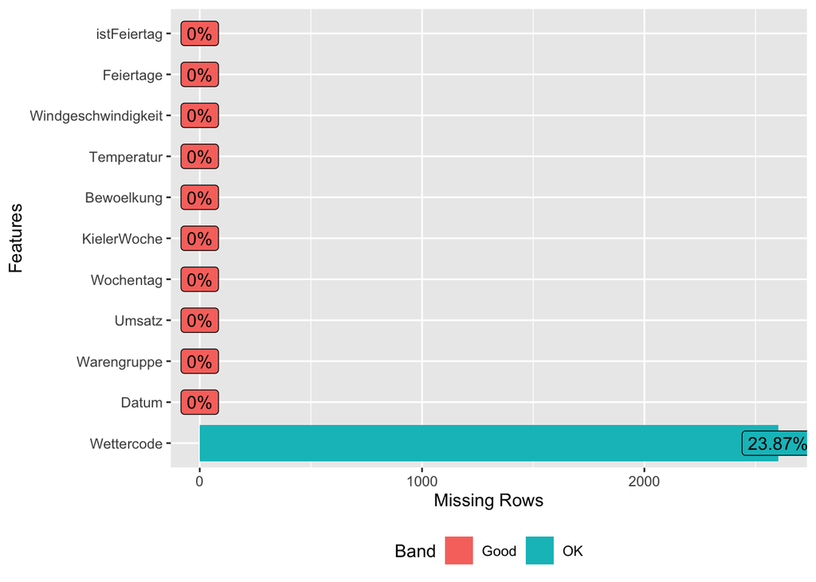

## Datenaufbereitung: Ausreißer bereinigen

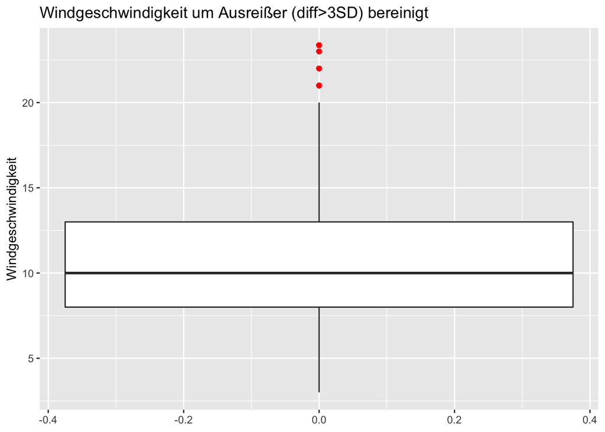

```r
#Ausreißer deckeln auf 3x Standardabweichung (Umsatz und Windgeschwindigkeit sind betroffen.)
#Bei 2x Standardabweichung werden 5% der Daten beeinflusst, das halte ich für zu viel. NUN 30.05.2021
#Standardabweichung berechnen (sd(x))
sd_Umsatz<-sd(dataset$Umsatz, na.rm=TRUE)

sd_Windgeschwindigkeit<-sd(dataset$Windgeschwindigkeit, na.rm=TRUE)

#Gefundene Werte auf 3x Standardabweichung setzen
dataset$Windgeschwindigkeit[dataset$Windgeschwindigkeit > (mean(dataset$Windgeschwindigkeit) + sd_Windgeschwindigkeit*3)]<- (mean(dataset$Windgeschwindigkeit) + sd_Windgeschwindigkeit*3)
dataset$Windgeschwindigkeit[dataset$Windgeschwindigkeit < (mean(dataset$Windgeschwindigkeit) - sd_Windgeschwindigkeit*3)]<- (mean(dataset$Windgeschwindigkeit) - sd_Windgeschwindigkeit*3)
dataset$Umsatz[dataset$Umsatz > (mean(dataset$Umsatz) + sd_Umsatz*3)]<- (mean(dataset$Umsatz) + sd_Umsatz*3)
dataset$Umsatz[dataset$Umsatz < (mean(dataset$Umsatz) - sd_Umsatz*3)]<- (mean(dataset$Umsatz) - sd_Umsatz*3)

ggplot(dataset) + geom_boxplot(aes(y=Windgeschwindigkeit),outlier.colour="red")+ coord_cartesian(ylim = c(min(dataset$Windgeschwindigkeit), max(dataset$Windgeschwindigkeit)))+ggtitle("Windgeschwindigkeit um Ausreißer (diff>3SD) bereinigt")
```

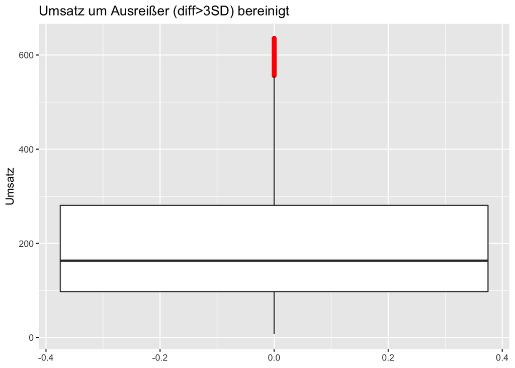

```r
ggplot(dataset) + geom_boxplot(aes(y=Umsatz),outlier.colour="red")+ coord_cartesian(ylim = c(min(dataset$Umsatz), max(dataset$Umsatz)))+ggtitle("Umsatz um Ausreißer (diff>3SD) bereinigt")
```

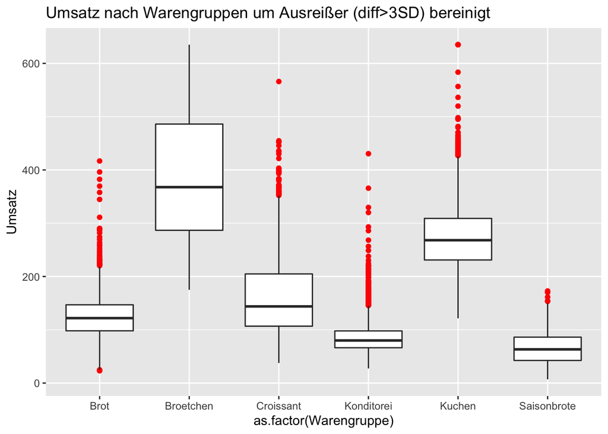

```r
ggplot(dataset) +
geom_boxplot(aes(x=as.factor(Warengruppe), y=Umsatz),outlier.colour="red")+ coord_cartesian(ylim = c(min(dataset$Umsatz), max(dataset$Umsatz)))+ggtitle("Umsatz nach Warengruppen um Ausreißer (diff>3SD) bereinigt")
```

```r
rm(sd_Umsatz, sd_Windgeschwindigkeit)
```

# Datensets für Modellierungen bereitstellen

## Trainingsdatensätze erstellen

- data1 : Faktoren bei Warengruppe und Wochentag bleiben erhalten, Variablen Wettercode und (Bezeichnung der) Feiertage raus
- data2 : Wie data1, aber alle Variablen numerisch

```r
str(data1)
```

```
## tibble [10,899 × 9] (S3: tbl_df/tbl/data.frame)
##  $ Datum              : Date[1:10899], format: "2013-07-01" "2013-07-02" ...
##  $ Warengruppe        : Factor w/ 6 levels "Brot","Broetchen",..: 1 1 1 1 1 1 1 1 1 1 ...
##  $ Umsatz             : num [1:10899] 149 160 112 169 171 ...
##  $ Wochentag          : Factor w/ 7 levels "Montag","Dienstag",..: 1 2 3 4 5 6 7 1 2 3 ...
##  $ KielerWoche        : num [1:10899] 0 0 0 0 0 0 0 0 0 0 ...
##  $ Bewoelkung         : num [1:10899] 6 3 7 7 5 0 0 0 0 2 ...
##  $ Temperatur         : num [1:10899] 17.8 17.3 21.1 18.9 20 ...
##  $ Windgeschwindigkeit: num [1:10899] 15 10 6 7 12 8 9 10 8 13 ...
##  $ istFeiertag        : num [1:10899] 0 0 0 0 0 0 0 0 0 0 ...
```

```r
str(data2)
```

```
## tibble [10,899 × 9] (S3: tbl_df/tbl/data.frame)
##  $ Datum              : Date[1:10899], format: "2013-07-01" "2013-07-02" ...
##  $ Warengruppe        : num [1:10899] 1 1 1 1 1 1 1 1 1 1 ...
##  $ Umsatz             : num [1:10899] 149 160 112 169 171 ...
##  $ Wochentag          : num [1:10899] 1 2 3 4 5 6 7 1 2 3 ...
##  $ KielerWoche        : num [1:10899] 0 0 0 0 0 0 0 0 0 0 ...
##  $ Bewoelkung         : num [1:10899] 6 3 7 7 5 0 0 0 0 2 ...
##  $ Temperatur         : num [1:10899] 17.8 17.3 21.1 18.9 20 ...
##  $ Windgeschwindigkeit: num [1:10899] 15 10 6 7 12 8 9 10 8 13 ...
##  $ istFeiertag        : num [1:10899] 0 0 0 0 0 0 0 0 0 0 ...
```

## Vorhersagedatensatz mit gleicher Struktur erzeugen

Prädiktion wird vorbereitet für Umsätze 7.6.2019 (Freitag, erster Tag nach Ende der Umsatzdaten) und 09.6.2019 (Sonntag darauf) und zum Kontrast ein stürmischer kalter Mittwoch im Januar 09.01.2019

- pred_data1: Passend zu data1 mit Faktorenstrukturen
- pred_data2: Passend zu data2 mit nur numerischen Variablen

```r
str(pred_data1)
```

```
## 'data.frame':    18 obs. of  8 variables:
##  $ Warengruppe        : Factor w/ 6 levels "Brot","Broetchen",..: 1 1 1 2 2 2 3 3 3 4 ...
##  $ Datum              : Date, format: "2019-06-07" "2019-06-09" ...
##  $ Wochentag          : Factor w/ 7 levels "Montag","Dienstag",..: 5 7 3 5 7 3 5 7 3 5 ...
##  $ KielerWoche        : num  0 0 0 0 0 0 0 0 0 0 ...
##  $ Bewoelkung         : num  1 5 7 1 5 7 1 5 7 1 ...
##  $ Temperatur         : num  17.45 18.65 3.14 17.45 18.65 ...
##  $ Windgeschwindigkeit: num  10 10 22 10 10 22 10 10 22 10 ...
##  $ istFeiertag        : num  0 0 0 0 0 0 0 0 0 0 ...
```

```r
str(pred_data2)
```

```
## 'data.frame':    18 obs. of  8 variables:
##  $ Warengruppe        : num  1 1 1 2 2 2 3 3 3 4 ...
##  $ Datum              : Date, format: "2019-06-07" "2019-06-09" ...
##  $ Wochentag          : num  5 7 3 5 7 3 5 7 3 5 ...
##  $ KielerWoche        : num  0 0 0 0 0 0 0 0 0 0 ...
##  $ Bewoelkung         : num  1 5 7 1 5 7 1 5 7 1 ...
##  $ Temperatur         : num  17.45 18.65 3.14 17.45 18.65 ...
##  $ Windgeschwindigkeit: num  10 10 22 10 10 22 10 10 22 10 ...
##  $ istFeiertag        : num  0 0 0 0 0 0 0 0 0 0 ...
```

# Balken-Diagramme für selbsterstellte Variablen mit Angaben zur Streuung (Umsätze je Wochentag)

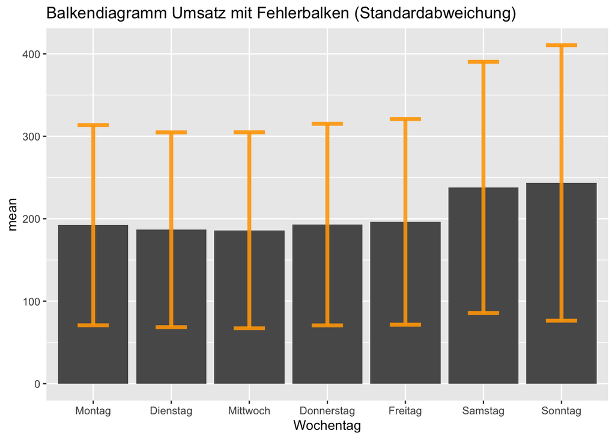

```r
# Calculates mean, sd, se and IC für Umsatzdaten pro Wochentag
data1_sum <- data1 %>%
  group_by(Wochentag) %>%
  summarise(
    n=n(),
    mean=mean(Umsatz),
    sd=sd(Umsatz)
  ) %>%
  mutate( se=sd/sqrt(n))  %>%
  mutate( ic=se * qt((1-0.05)/2 + .5, n-1))



ggplot(data1_sum) +
  geom_bar( aes(x=Wochentag, y=mean), stat="identity") +
  geom_errorbar( aes(x=Wochentag, ymin=mean-sd, ymax=mean+sd), width=0.4, colour="orange", alpha=0.9, size=1.5) + scale_x_discrete(limits = ordentlicheWoche) +
  ggtitle("Balkendiagramm Umsatz mit Fehlerbalken (Standardabweichung) ")
```

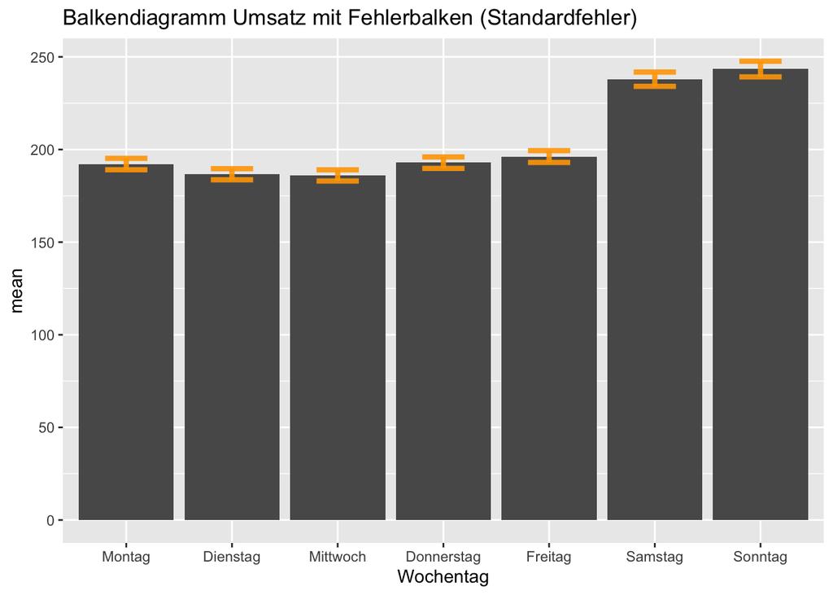

```r
ggplot(data1_sum) +
  geom_bar( aes(x=Wochentag, y=mean), stat="identity") +
  geom_errorbar( aes(x=Wochentag, ymin=mean-se, ymax=mean+se), width=0.4, colour="orange", alpha=0.9, size=1.5) + scale_x_discrete(limits = ordentlicheWoche) +
  ggtitle("Balkendiagramm Umsatz mit Fehlerbalken (Standardfehler) ")
```

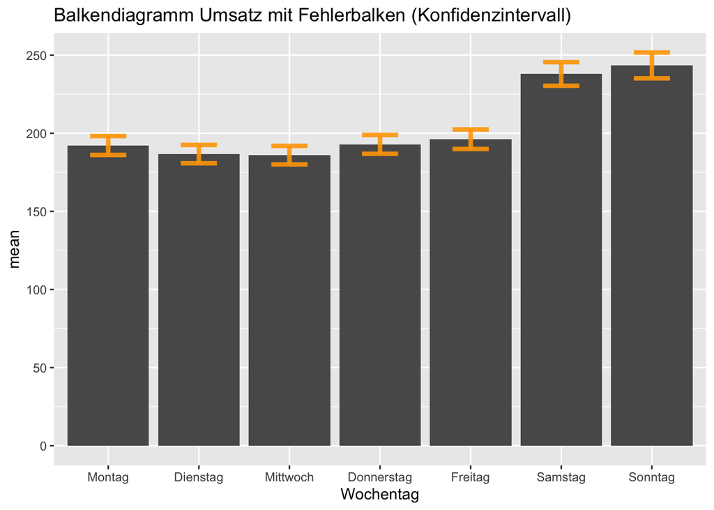

```r
ggplot(data1_sum) +
  geom_bar( aes(x=Wochentag, y=mean), stat="identity") +
  geom_errorbar( aes(x=Wochentag, ymin=mean-ic, ymax=mean+ic), width=0.4, colour="orange", alpha=0.9, size=1.5) + scale_x_discrete(limits = ordentlicheWoche) +
  ggtitle("Balkendiagramm Umsatz mit Fehlerbalken (Konfidenzintervall) ")
```

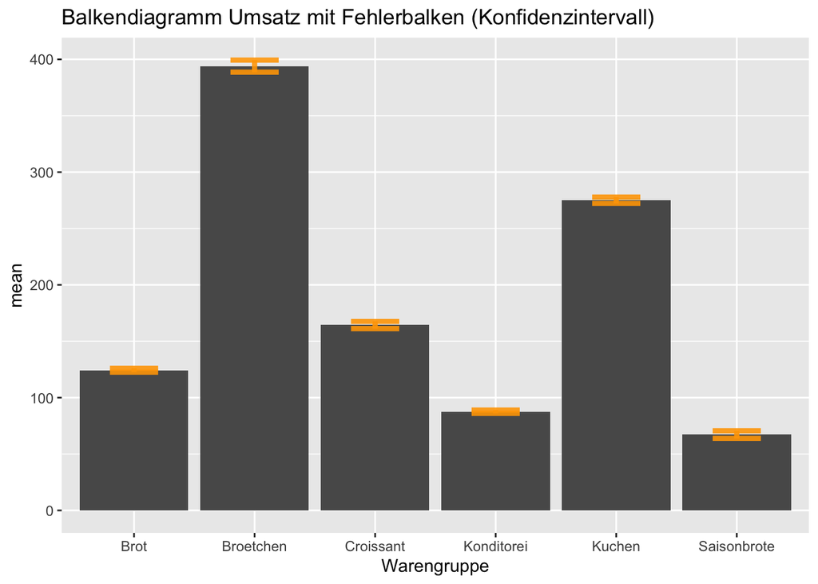

```r
# Calculates mean, sd, se and IC für Umsatzdaten pro Wochentag
data1_sum2 <- data1 %>%
  group_by(Warengruppe) %>%
  summarise(
    n=n(),
    mean=mean(Umsatz),
    sd=sd(Umsatz)
  ) %>%
  mutate( se=sd/sqrt(n))  %>%
  mutate( ic=se * qt((1-0.05)/2 + .5, n-1))





ggplot(data1_sum2) +
  geom_bar( aes(x=Warengruppe, y=mean), stat="identity") +
  geom_errorbar( aes(x=Warengruppe, ymin=mean-ic, ymax=mean+ic), width=0.4, colour="orange", alpha=0.9, size=1.5) + scale_x_discrete(limits = Warengruppen) +
  ggtitle("Balkendiagramm Umsatz mit Fehlerbalken (Konfidenzintervall) ")
```

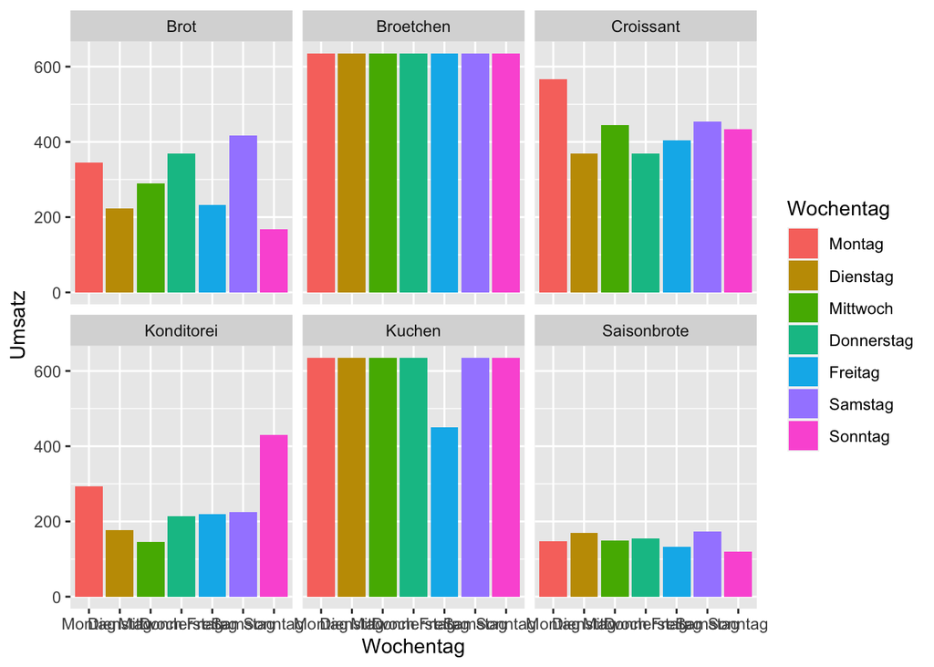

```r
ggplot(data1, aes(fill=Wochentag, y=Umsatz, x=Wochentag)) +
  geom_bar(position="dodge", stat="identity")+facet_wrap(~Warengruppe)
```

# Lineare Modelle/Supervised Learning

## Optimierung des Modells mit schrittweiser Aufnahme von Variablen

|  | Model 1 | Model 2 | Model 3 | Model 4 | Model 5 | Model 6 | Model 7 |
| --- | --- | --- | --- | --- | --- | --- | --- |
| (Intercept) | 124.32 *** | 111.30 *** | 108.97 *** | 62.59 *** | 62.78 *** | 58.70 *** | 60.18 *** |
|  | (1.62) | (2.28) | (2.28) | (2.34) | (2.34) | (2.90) | (3.29) |
| WarengruppeBroetchen | 269.66 *** | 269.66 *** | 269.66 *** | 269.66 *** | 269.66 *** | 269.66 *** | 269.66 *** |
|  | (2.30) | (2.18) | (2.18) | (2.00) | (2.00) | (2.00) | (2.00) |
| WarengruppeCroissant | 40.12 *** | 40.12 *** | 40.12 *** | 40.12 *** | 40.12 *** | 40.12 *** | 40.12 *** |
|  | (2.30) | (2.18) | (2.18) | (2.00) | (2.00) | (2.00) | (2.00) |
| WarengruppeKonditorei | -36.81 *** | -36.97 *** | -36.99 *** | -36.83 *** | -36.83 *** | -36.82 *** | -36.82 *** |
|  | (2.31) | (2.20) | (2.19) | (2.01) | (2.01) | (2.01) | (2.01) |
| WarengruppeKuchen | 150.73 *** | 150.73 *** | 150.73 *** | 150.73 *** | 150.73 *** | 150.73 *** | 150.73 *** |
|  | (2.30) | (2.18) | (2.18) | (2.00) | (2.00) | (2.00) | (2.00) |
| WarengruppeSaisonbrote | -57.11 *** | -57.06 *** | -56.34 *** | -35.48 *** | -35.37 *** | -35.08 *** | -35.00 *** |
|  | (4.32) | (4.11) | (4.10) | (3.80) | (3.80) | (3.80) | (3.80) |
| WochentagDienstag |  | -5.43 * | -3.33 | -4.06 | -4.04 | -4.05 | -4.01 |
|  |  | (2.55) | (2.55) | (2.34) | (2.34) | (2.34) | (2.34) |
| WochentagMittwoch |  | -6.71 ** | -4.61 | -5.78 * | -5.76 * | -5.79 * | -5.78 * |
|  |  | (2.56) | (2.55) | (2.35) | (2.35) | (2.35) | (2.35) |
| WochentagDonnerstag |  | 1.29 | 2.14 | 1.14 | 1.15 | 1.23 | 1.29 |
|  |  | (2.55) | (2.54) | (2.34) | (2.33) | (2.33) | (2.33) |
| WochentagFreitag |  | 4.01 | 6.11 * | 4.79 * | 4.82 * | 4.89 * | 4.93 * |
|  |  | (2.56) | (2.56) | (2.35) | (2.35) | (2.35) | (2.35) |
| WochentagSamstag |  | 45.60 *** | 47.71 *** | 47.78 *** | 47.57 *** | 47.67 *** | 47.71 *** |
|  |  | (2.55) | (2.55) | (2.34) | (2.34) | (2.34) | (2.34) |
| WochentagSonntag |  | 51.95 *** | 54.05 *** | 53.31 *** | 53.09 *** | 53.09 *** | 53.08 *** |
|  |  | (2.55) | (2.55) | (2.34) | (2.34) | (2.34) | (2.34) |
| istFeiertag |  |  | 65.21 *** | 58.20 *** | 58.54 *** | 58.18 *** | 57.94 *** |
|  |  |  | (6.69) | (6.16) | (6.15) | (6.15) | (6.16) |
| Temperatur |  |  |  | 3.93 *** | 3.89 *** | 3.89 *** | 3.86 *** |
|  |  |  |  | (0.09) | (0.09) | (0.09) | (0.10) |
| KielerWoche |  |  |  |  | 14.46 ** | 14.25 ** | 14.54 ** |
|  |  |  |  |  | (4.45) | (4.45) | (4.46) |
| Windgeschwindigkeit |  |  |  |  |  | 0.37 * | 0.38 * |
|  |  |  |  |  |  | (0.16) | (0.16) |
| Bewoelkung |  |  |  |  |  |  | -0.25 |
|  |  |  |  |  |  |  | (0.26) |
| N | 10899 | 10899 | 10899 | 10899 | 10899 | 10899 | 10899 |
| R2 | 0.69 | 0.72 | 0.73 | 0.77 | 0.77 | 0.77 | 0.77 |
| *** p < 0.001; ** p < 0.01; * p < 0.05. |  |  |  |  |  |  |  |

```
## Analysis of Variance Table
##
## Model 1: Umsatz ~ Warengruppe
## Model 2: Umsatz ~ Warengruppe + Wochentag
## Model 3: Umsatz ~ Warengruppe + Wochentag + istFeiertag
## Model 4: Umsatz ~ Warengruppe + Wochentag + istFeiertag + Temperatur
## Model 5: Umsatz ~ Warengruppe + Wochentag + istFeiertag + Temperatur +
##     KielerWoche
## Model 6: Umsatz ~ Warengruppe + Wochentag + istFeiertag + Temperatur +
##     KielerWoche + Windgeschwindigkeit
## Model 7: Umsatz ~ Warengruppe + Wochentag + istFeiertag + Temperatur +
##     KielerWoche + Windgeschwindigkeit + Bewoelkung
##   Res.Df      RSS Df Sum of Sq         F    Pr(>F)
## 1  10893 60872235
## 2  10887 55094668  6   5777567  227.0783 < 2.2e-16 ***
## 3  10886 54617735  1    476933  112.4707 < 2.2e-16 ***
## 4  10885 46217848  1   8399887 1980.8675 < 2.2e-16 ***
## 5  10884 46173133  1     44716   10.5449  0.001169 **
## 6  10883 46149114  1     24019    5.6642  0.017332 *
## 7  10882 46145221  1      3892    0.9179  0.338053
## ---
## Signif. codes:  0 '***' 0.001 '**' 0.01 '*' 0.05 '.' 0.1 ' ' 1
```

Entscheidung für das Modell 6 **Umsatz ~ Warengruppe + Wochentag + istFeiertag + Temperatur + KielerWoche + Windgeschwindigkeit** mit 0,77 Varianzaufklärung, da noch sig. besser als Modell 5 laut Modellvergleich

```
## MODEL INFO:
## Observations: 10899
## Dependent Variable: Umsatz
## Type: OLS linear regression
##
## MODEL FIT:
## F(15,10883) = 2410.29, p = 0.00
## R² = 0.77
## Adj. R² = 0.77
##
## Standard errors: OLS
## ------------------------------------------------------------
##                                  Est.   S.E.   t val.      p
## ---------------------------- -------- ------ -------- ------
## (Intercept)                     58.70   2.90    20.21   0.00
## WarengruppeBroetchen           269.66   2.00   134.85   0.00
## WarengruppeCroissant            40.12   2.00    20.06   0.00
## WarengruppeKonditorei          -36.82   2.01   -18.29   0.00
## WarengruppeKuchen              150.73   2.00    75.38   0.00
## WarengruppeSaisonbrote         -35.08   3.80    -9.24   0.00
## WochentagDienstag               -4.05   2.34    -1.73   0.08
## WochentagMittwoch               -5.79   2.35    -2.46   0.01
## WochentagDonnerstag              1.23   2.33     0.53   0.60
## WochentagFreitag                 4.89   2.35     2.08   0.04
## WochentagSamstag                47.67   2.34    20.34   0.00
## WochentagSonntag                53.09   2.34    22.68   0.00
## istFeiertag                     58.18   6.15     9.45   0.00
## Temperatur                       3.89   0.09    43.69   0.00
## KielerWoche                     14.25   4.45     3.20   0.00
## Windgeschwindigkeit              0.37   0.16     2.38   0.02
## ------------------------------------------------------------
```

## Prädiktion 1 (Lineare Modelle/Supervised Learning)

aka: Ich nehme ein lineares Modell, das auf einen Datensatz gefittet wurde und sage mit den dort geschätzten Koeffizienten die Zielvariable auf Basis von einem neuen Datensatz vorher

```r
#Vorhersage berechnen
pred_lm <- predict(object=LMfinal, newdata = pred_data1, type = "response", interval = "confidence", na.action = na.exclude)

#print(pred_lm)
#class(pred_lm)#is ne doofe Matrix--> für Nutzung von dplyr-Routinen as.data.frame()

pred_lm <- dplyr::bind_cols(pred_data1, as.data.frame(pred_lm)) #in dieser Datei sind "fit" die Umsatz-Prädiktionen für die jeweiligen Datenpunkte, lwr und upr sind die Grenzen der Konfidenzintervalle


pred_lm<- rename(pred_lm,Prediction_Umsatz_LM = fit,UntereGrenzeKonfInt=lwr,ObereGrenzeKonfInt=upr)

anzeige <-dplyr::filter(pred_lm,Datum==ymd(20190607))
anzeige <-dplyr::select(anzeige, c("Warengruppe","Prediction_Umsatz_LM","UntereGrenzeKonfInt","ObereGrenzeKonfInt"))
pred_lm
```

```
##    Warengruppe      Datum Wochentag KielerWoche Bewoelkung Temperatur
## 1         Brot 2019-06-07   Freitag           0          1    17.4500
## 2         Brot 2019-06-09   Sonntag           0          5    18.6500
## 3         Brot 2019-01-09  Mittwoch           0          7     3.1375
## 4    Broetchen 2019-06-07   Freitag           0          1    17.4500
## 5    Broetchen 2019-06-09   Sonntag           0          5    18.6500
## 6    Broetchen 2019-01-09  Mittwoch           0          7     3.1375
## 7    Croissant 2019-06-07   Freitag           0          1    17.4500
## 8    Croissant 2019-06-09   Sonntag           0          5    18.6500
## 9    Croissant 2019-01-09  Mittwoch           0          7     3.1375
## 10  Konditorei 2019-06-07   Freitag           0          1    17.4500
## 11  Konditorei 2019-06-09   Sonntag           0          5    18.6500
## 12  Konditorei 2019-01-09  Mittwoch           0          7     3.1375
## 13      Kuchen 2019-06-07   Freitag           0          1    17.4500
## 14      Kuchen 2019-06-09   Sonntag           0          5    18.6500
```

[output cut: 42 more lines]

**Die Vorhersage für den ersten Tag (2019-06-07) nach Ende der Datenreihe ist:**

Modell: Umsatz ~ Warengruppe + Wochentag + istFeiertag + Temperatur + KielerWoche + Windgeschwindigkeit

```
##    Warengruppe Prediction_Umsatz_LM UntereGrenzeKonfInt ObereGrenzeKonfInt
## 1         Brot            135.20687           130.98910           139.4246
## 4    Broetchen            404.86622           400.64845           409.0840
## 7    Croissant            175.32563           171.10787           179.5434
## 10  Konditorei             98.38697            94.14281           102.6311
## 13      Kuchen            285.93224           281.71447           290.1500
## 16 Saisonbrote            100.12620            92.42066           107.8317
```

# Support Vector Maschinen

## Trainings- und Testdatensätze erstellen

```r
data<-data2

# Zufallszähler setzen (um die zufällige Partitionierung bei jedem Durchlauf gleich zu halten)
set.seed(1)

#Datensatzzeilen shuffeln
new_row_order<-sample(nrow(data))
data<-data[new_row_order,]

# Zufällige Ziehung von Indizes für die Zeilen des Datensatzes, die dem Traininsdatensatz zugeordnet werden, Umfang: 80% (im Moment 10%)
indices_train <- sample(seq_len(nrow(data)), size = floor(0.80 * nrow(data)))

# Definition des Trainings- und Testdatensatz durch Selektion bzw. Deselektion der entsprechenden Datenzeilen
train_data <- data[indices_train, ]
test_data <- data[-indices_train, ]
```

## SVM Trainieren (ohne Tuning)

```r
model_svm <- svm(Umsatz ~ Warengruppe + Wochentag , train_data)
summary(model_svm)
```

```
##
## Call:
## svm(formula = Umsatz ~ Warengruppe + Wochentag, data = train_data)
##
##
## Parameters:
##    SVM-Type:  eps-regression
##  SVM-Kernel:  radial
##        cost:  1
##       gamma:  0.5
##     epsilon:  0.1
##
##
## Number of Support Vectors:  6404
```

## Kreuzvalidierung

```r
test_data_svm <-predict(model_svm,test_data,na.action = na.pass)
mape(test_data$Umsatz,test_data_svm) #Mean Absolute Percent Error,
```

```
## [1] 0.2470472
```

```r
#rse: sum(error^2)/sum(actual-mean(actual))
#r^2=1-rse #laut Steffen Brandt

r_squared_svm<-1-rse(test_data$Umsatz,test_data_svm)
r_squared_svm
```

```
## [1] 0.7407091
```

##Prädiktion 2 (SVM ohne Tuning)

```r
pred_svm <- predict(model_svm, pred_data2, na.action = na.pass)# Daten Vorhersagen

pred_svm  <- dplyr::bind_cols(pred_data2, as.data.frame(pred_svm  )) #zusammenfügen

pred_svm<- rename(pred_svm,Prediction_Umsatz_SVM = pred_svm)#Variablenbenennung anpassen

#Faktoren wieder schick machen
pred_svm$Wochentag <- factor(weekdays(pred_svm$Datum),
levels=ordentlicheWoche)
pred_svm$Warengruppe <- factor(pred_svm$Warengruppe,
levels = c(1,2,3,4,5,6),
labels = c("Brot", "Broetchen", "Croissant","Konditorei","Kuchen","Saisonbrote"))


anzeige <-dplyr::filter(pred_svm,Datum==ymd(20190607))
anzeige <-dplyr::select(anzeige, c("Warengruppe","Prediction_Umsatz_SVM"))

pred_svm
```

```
##    Warengruppe      Datum Wochentag KielerWoche Bewoelkung Temperatur
## 1         Brot 2019-06-07   Freitag           0          1    17.4500
## 2         Brot 2019-06-09   Sonntag           0          5    18.6500
## 3         Brot 2019-01-09  Mittwoch           0          7     3.1375
## 4    Broetchen 2019-06-07   Freitag           0          1    17.4500
## 5    Broetchen 2019-06-09   Sonntag           0          5    18.6500
## 6    Broetchen 2019-01-09  Mittwoch           0          7     3.1375
## 7    Croissant 2019-06-07   Freitag           0          1    17.4500
## 8    Croissant 2019-06-09   Sonntag           0          5    18.6500
## 9    Croissant 2019-01-09  Mittwoch           0          7     3.1375
## 10  Konditorei 2019-06-07   Freitag           0          1    17.4500
## 11  Konditorei 2019-06-09   Sonntag           0          5    18.6500
## 12  Konditorei 2019-01-09  Mittwoch           0          7     3.1375
## 13      Kuchen 2019-06-07   Freitag           0          1    17.4500
## 14      Kuchen 2019-06-09   Sonntag           0          5    18.6500
```

[output cut: 23 more lines]

**Die Vorhersage für den ersten Tag (2019-06-07) nach Ende der Datenreihe ist:**

Modell: Umsatz ~ Warengruppe + Wochentag

```
##    Warengruppe Prediction_Umsatz_SVM
## 1         Brot             133.72062
## 4    Broetchen             361.75934
## 7    Croissant             134.11515
## 10  Konditorei              74.21082
## 13      Kuchen             271.40650
## 16 Saisonbrote              73.94131
```

## SVM Trainieren (mit Tuning)

```r
svm_tune <- tune(svm, Umsatz ~ Warengruppe + Wochentag, data=train_data,ranges = list(epsilon = seq(0.2,1,0.1), cost = 2^(2:3)))
summary(svm_tune)
```

```
##
## Parameter tuning of 'svm':
##
## - sampling method: 10-fold cross validation
##
## - best parameters:
##  epsilon cost
##      0.3    8
##
## - best performance: 4600.943
##
## - Detailed performance results:
##    epsilon cost    error dispersion
## 1      0.2    4 4628.919   510.3438
## 2      0.3    4 4613.143   502.6904
## 3      0.4    4 4625.071   484.8863
## 4      0.5    4 4716.297   465.7174
## 5      0.6    4 4922.799   442.9660
## 6      0.7    4 5267.285   393.2036
## 7      0.8    4 5816.886   361.3550
## 8      0.9    4 6483.113   329.3715
## 9      1.0    4 7392.684   273.7593
## 10     0.2    8 4616.078   504.2814
## 11     0.3    8 4600.943   500.5693
## 12     0.4    8 4610.700   478.6521
## 13     0.5    8 4689.747   467.1254
## 14     0.6    8 4881.457   433.4667
## 15     0.7    8 5211.009   394.4480
## 16     0.8    8 5740.479   361.5042
## 17     0.9    8 6374.043   372.5208
## 18     1.0    8 7285.123   307.5429
```

## Kreuzvalidierung

```r
test_data_svm<-predict(svm_tune$best.model,test_data,na.action = na.pass)
mape(test_data$Umsatz,test_data_svm) #Mean Absolute Percent Error
```

```
## [1] 0.2657663
```

```r
r_squared_svmtune<-1-rse(test_data$Umsatz,test_data_svm)
r_squared_svmtune
```

```
## [1] 0.7447464
```

## Prädiktion 3 (SVM mit Tuning)

```r
pred_svmtune <- predict(svm_tune$best.model, pred_data2, na.action = na.pass)# Daten Vorhersagen

pred_svmtune  <- dplyr::bind_cols(pred_data2, as.data.frame(pred_svmtune)) #zusammenfügen

pred_svmtune<- rename(pred_svmtune,Prediction_Umsatz_SVMtune = pred_svmtune)#Variablenbenennung anpassen

#Faktoren wieder schick machen
pred_svmtune$Wochentag <- factor(weekdays(pred_svmtune$Datum),
levels=ordentlicheWoche)
pred_svmtune$Warengruppe <- factor(pred_svmtune$Warengruppe,
levels = c(1,2,3,4,5,6),
labels = c("Brot", "Broetchen", "Croissant","Konditorei","Kuchen","Saisonbrote"))


anzeige <-dplyr::filter(pred_svmtune,Datum==ymd(20190607))
anzeige <-dplyr::select(anzeige, c("Warengruppe","Prediction_Umsatz_SVMtune"))

pred_svmtune
```

```
##    Warengruppe      Datum Wochentag KielerWoche Bewoelkung Temperatur
## 1         Brot 2019-06-07   Freitag           0          1    17.4500
## 2         Brot 2019-06-09   Sonntag           0          5    18.6500
## 3         Brot 2019-01-09  Mittwoch           0          7     3.1375
## 4    Broetchen 2019-06-07   Freitag           0          1    17.4500
## 5    Broetchen 2019-06-09   Sonntag           0          5    18.6500
## 6    Broetchen 2019-01-09  Mittwoch           0          7     3.1375
## 7    Croissant 2019-06-07   Freitag           0          1    17.4500
## 8    Croissant 2019-06-09   Sonntag           0          5    18.6500
## 9    Croissant 2019-01-09  Mittwoch           0          7     3.1375
## 10  Konditorei 2019-06-07   Freitag           0          1    17.4500
## 11  Konditorei 2019-06-09   Sonntag           0          5    18.6500
## 12  Konditorei 2019-01-09  Mittwoch           0          7     3.1375
## 13      Kuchen 2019-06-07   Freitag           0          1    17.4500
## 14      Kuchen 2019-06-09   Sonntag           0          5    18.6500
```

[output cut: 23 more lines]

**Die Vorhersage für den ersten Tag (2019-06-07) nach Ende der Datenreihe ist:**

Modell: Umsatz ~ Warengruppe + Wochentag

```
##    Warengruppe Prediction_Umsatz_SVMtune
## 1         Brot                 134.27523
## 4    Broetchen                 354.63192
## 7    Croissant                 141.14587
## 10  Konditorei                  85.91749
## 13      Kuchen                 274.79435
## 16 Saisonbrote                  72.04234
```

# Vorbereitung

## Installation von Python und TensorFlow (nur einmalig nötig, im Hintergrund)

## Benötigte Pakete laden (im Hintergrund)

## Daten aufbereiten (im Hintergrund)

# Training des Neuronalen Netzes

## Definition des Neuronalen Netzes

```python
# Import needed Python libraries and functions
import numpy as np
import tensorflow as tf
from tensorflow.keras.layers import Dense
from tensorflow.keras.layers import Dropout
from tensorflow.keras.optimizers import Adam
from tensorflow.keras.layers.experimental import preprocessing
# Create a Normalization layer and use the means and variances of the training features for the normalization
normalizer = preprocessing.Normalization()
normalizer.adapt(r.training_features.values)
# The argument "shape" for the definition of the input layer must include the number of variables (features) used for the model. To automatically calculate this number, we use the "r.training_features.keys()", which returns the list of variable names of the dataframe "training_features". Further, the function len() returns the length of this list of variable names (i.e. the number of variables in the input).
inputs = tf.keras.Input(shape=[len(r.training_features.keys())])
# Normalization layer
x = normalizer(inputs)
# 1st hidden layer
x = Dense(10, activation='relu')(x)
x = Dropout(.2)(x)
# 2nd hidden layer
x = Dense(4, activation='relu')(x)
# Output layer
output = tf.keras.layers.Dense(1)(x)
# Model definition
model = tf.keras.Model(inputs, output)
# Ausgabe einer Zusammenfassung zur Form des Modells, das geschaetzt wird (nicht notwendig)
model.summary()
```

```
## Model: "model"
## _________________________________________________________________
## Layer (type)                 Output Shape              Param #
## =================================================================
## input_1 (InputLayer)         [(None, 15)]              0
## _________________________________________________________________
## normalization (Normalization (None, 15)                31
## _________________________________________________________________
## dense (Dense)                (None, 10)                160
## _________________________________________________________________
## dropout (Dropout)            (None, 10)                0
## _________________________________________________________________
## dense_1 (Dense)              (None, 4)                 44
## _________________________________________________________________
## dense_2 (Dense)              (None, 1)                 5
## =================================================================
## Total params: 240
## Trainable params: 209
## Non-trainable params: 31
## _________________________________________________________________
```

## Schätzung des neuronalen Netzes

```python
# Definition der Kosten-(Loss-)Funktion und der Optimierungsfunktion mit seinen Hyperparametern
model.compile(loss="mse", optimizer=Adam(lr=0.001))
# Schaetzung des Modells
history = model.fit(r.training_features, r.training_labels, epochs=100,
                    validation_data = (r.validation_features, r.validation_labels), verbose=0)
# Ggf. Speichern des geschaetzten Modells
model.save("python_model.h5")
```

## Auswertung der Modelloptimierung

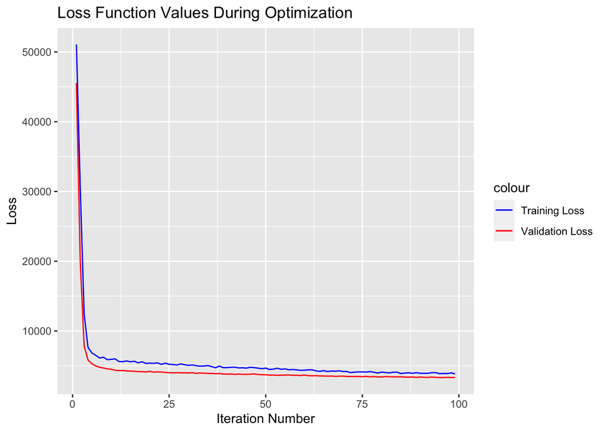

```r
# Grafische Ausgabe der Modelloptimierung
# create data
data <- data.frame(val_loss = unlist(py$history$history$val_loss),
                  loss = unlist(py$history$history$loss))
# Plot
ggplot(data[-1,]) +
  geom_line( aes(x=1:length(val_loss), y=val_loss, colour = "Validation Loss" )) +
  geom_line( aes(x=1:length(loss), y=loss, colour = "Training Loss" )) +
  scale_colour_manual( values = c("Training Loss"="blue", "Validation Loss"="red") ) +
  labs(title="Loss Function Values During Optimization") +
  xlab("Iteration Number") +
  ylab("Loss")
```

## (Ggf.) Laden eines gespeicherten Neuronalen Netzes

```python
model = tf.keras.models.load_model("python_model.h5")
```

## Auswertung der Schätzergebnisse

```r
# Schätzung der (normierten) Preise für die Trainings- und Testdaten
training_predictions <- py$model$predict(training_features)
validation_predictions <- py$model$predict(validation_features)
validation_true_predictions <- py$model$predict(pred_data_features)
# Vergleich der Gütekriterien für die Trainings- und Testdaten
cat(paste0("MAPE on the Training Data:\t", format(mape(training_labels[[1]], as.numeric(training_predictions))*100, digits=3, nsmall=2)))
```

```
## MAPE on the Training Data:   23.97
```

```r
cat(paste0("\nMAPE on the Validation Data:\t", format(mape(validation_labels[[1]], validation_predictions)*100, digits=3, nsmall=2)))
```

```
##
## MAPE on the Validation Data: 23.72
```

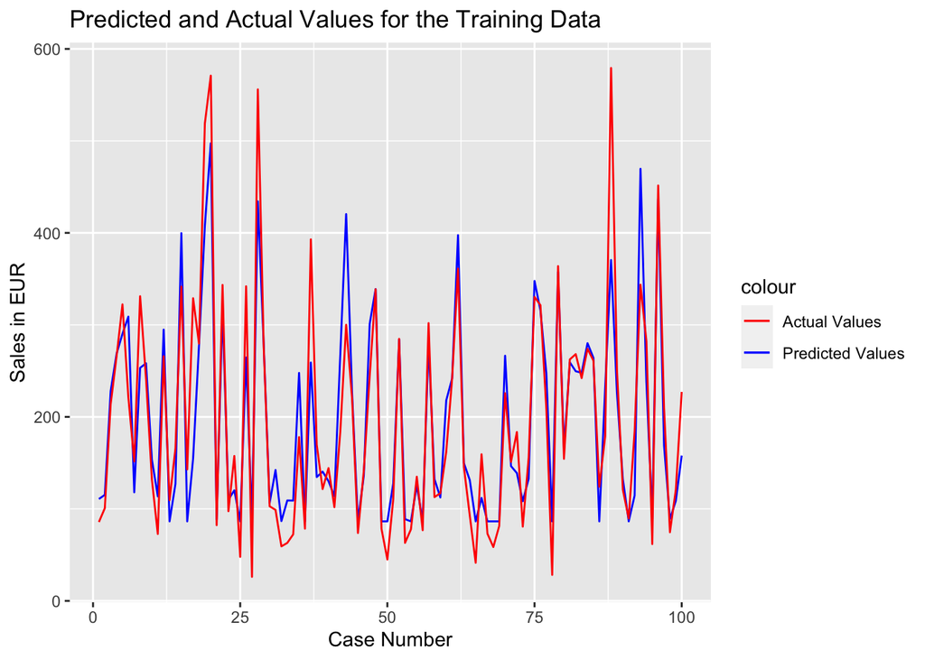

```r
## Grafischer vergleich der vorhergesagten und der tatsächlichen Preise für die Trainings- und Testdaten
# Zusammenstellung der Daten für die Plots
data_train <- data.frame(prediction = training_predictions, actual = training_labels[[1]])
data_test <- data.frame(prediction = validation_predictions, actual = validation_labels[[1]])
data_pred <- data.frame(prediction = validation_true_predictions)
# Plot der Ergebnisse der Trainingsdaten
ggplot(data_train[1:100,]) +
  geom_line( aes(x=1:length(prediction), y=prediction, colour = "Predicted Values" )) +
  geom_line( aes(x=1:length(actual), y=actual, colour = "Actual Values" )) +
  scale_colour_manual( values = c("Predicted Values"="blue", "Actual Values"="red") ) +
  labs(title="Predicted and Actual Values for the Training Data") +
  xlab("Case Number") +
  ylab("Sales in EUR")
```

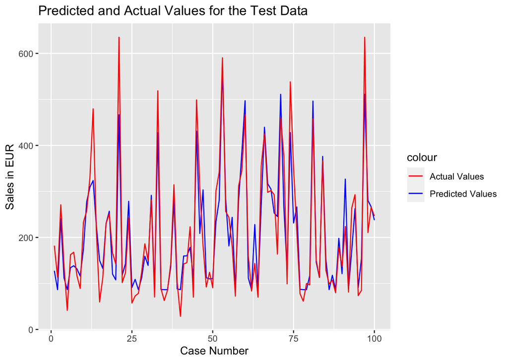

```r
# Plot der Ergebnisse der Validierungsdaten
ggplot(data_test[1:100,]) +
  geom_line( aes(x=1:length(prediction), y=prediction, colour = "Predicted Values" )) +
  geom_line( aes(x=1:length(actual), y=actual, colour = "Actual Values" )) +
  scale_colour_manual( values = c("Predicted Values"="blue", "Actual Values"="red") ) +
  labs(title="Predicted and Actual Values for the Test Data") +
  xlab("Case Number") +
  ylab("Sales in EUR")
```

## Prädiktion 4 (Neuronales Netz)

```r
pred_nn  <- dplyr::bind_cols(pred_data2, as.data.frame(data_pred)) #zusammenfügen

pred_nn<- rename(pred_nn,Prediction_Umsatz_nn = prediction)#Variablenbenennung anpassen

#Faktoren wieder schick machen
pred_nn$Wochentag <- factor(weekdays(pred_nn$Datum),
levels=ordentlicheWoche)
pred_nn$Warengruppe <- factor(pred_nn$Warengruppe,
levels = c(1,2,3,4,5,6),
labels = Warengruppen)


anzeige <-dplyr::filter(pred_nn,Datum==ymd(20190607))
anzeige <-dplyr::select(anzeige, c("Warengruppe","Prediction_Umsatz_nn"))

pred_nn
```

```
##    Warengruppe      Datum Wochentag KielerWoche Bewoelkung Temperatur
## 1         Brot 2019-06-07   Freitag           0          1    17.4500
## 2         Brot 2019-06-09   Sonntag           0          5    18.6500
## 3         Brot 2019-01-09  Mittwoch           0          7     3.1375
## 4    Broetchen 2019-06-07   Freitag           0          1    17.4500
## 5    Broetchen 2019-06-09   Sonntag           0          5    18.6500
## 6    Broetchen 2019-01-09  Mittwoch           0          7     3.1375
## 7    Croissant 2019-06-07   Freitag           0          1    17.4500
## 8    Croissant 2019-06-09   Sonntag           0          5    18.6500
## 9    Croissant 2019-01-09  Mittwoch           0          7     3.1375
## 10  Konditorei 2019-06-07   Freitag           0          1    17.4500
## 11  Konditorei 2019-06-09   Sonntag           0          5    18.6500
## 12  Konditorei 2019-01-09  Mittwoch           0          7     3.1375
## 13      Kuchen 2019-06-07   Freitag           0          1    17.4500
## 14      Kuchen 2019-06-09   Sonntag           0          5    18.6500
```

[output cut: 23 more lines]

**Die Vorhersage für den ersten Tag (2019-06-07) nach Ende der Datenreihe ist:**

Variablen die im NN eingehen: Bewoelkung KielerWoche Temperatur Windgeschwindigkeit warengruppe_dummies wochentag_dummies

```
##   Warengruppe Prediction_Umsatz_nn
## 1        Brot            137.45241
## 2   Broetchen            409.28732
## 3   Croissant            166.69601
## 4  Konditorei             87.31030
## 5      Kuchen            277.11057
## 6 Saisonbrote             86.45187
```

# Grafischer Vergleich der Vorhersagen

```
##    Warengruppe      Datum Wochentag KielerWoche Bewoelkung Temperatur
## 1         Brot 2019-06-07   Freitag           0          1    17.4500
## 2         Brot 2019-06-09   Sonntag           0          5    18.6500
## 3         Brot 2019-01-09  Mittwoch           0          7     3.1375
## 4    Broetchen 2019-06-07   Freitag           0          1    17.4500
## 5    Broetchen 2019-06-09   Sonntag           0          5    18.6500
## 6    Broetchen 2019-01-09  Mittwoch           0          7     3.1375
## 7    Croissant 2019-06-07   Freitag           0          1    17.4500
## 8    Croissant 2019-06-09   Sonntag           0          5    18.6500
## 9    Croissant 2019-01-09  Mittwoch           0          7     3.1375
## 10  Konditorei 2019-06-07   Freitag           0          1    17.4500
## 11  Konditorei 2019-06-09   Sonntag           0          5    18.6500
## 12  Konditorei 2019-01-09  Mittwoch           0          7     3.1375
## 13      Kuchen 2019-06-07   Freitag           0          1    17.4500
## 14      Kuchen 2019-06-09   Sonntag           0          5    18.6500
```

[output cut: 42 more lines]

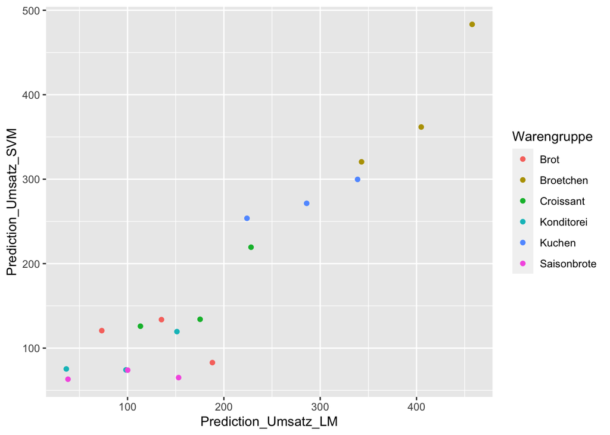

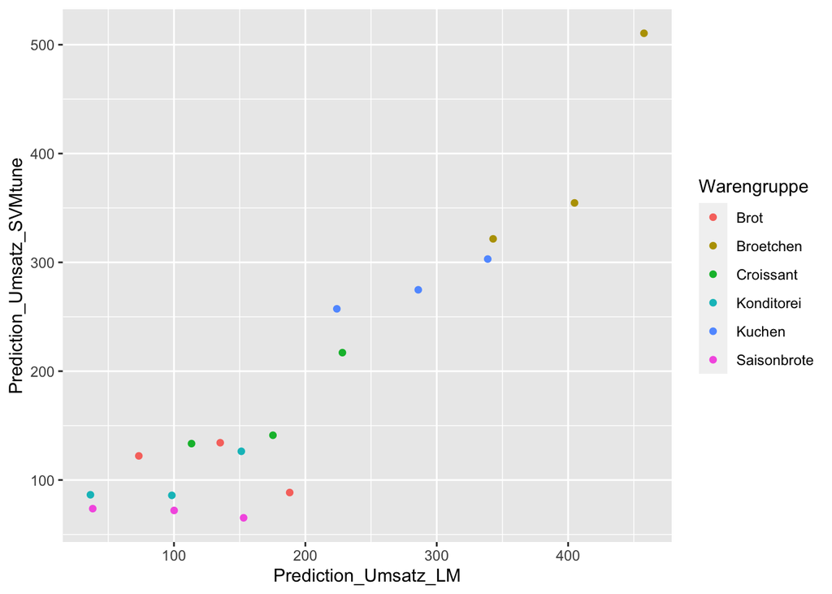

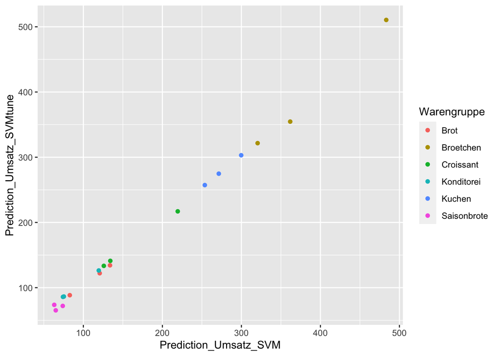

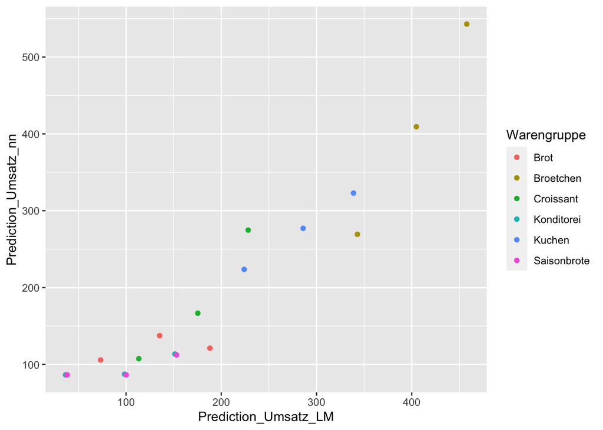

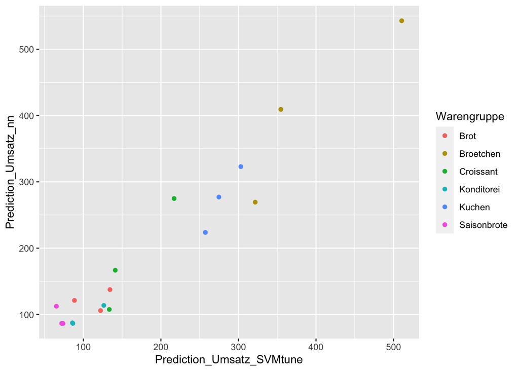

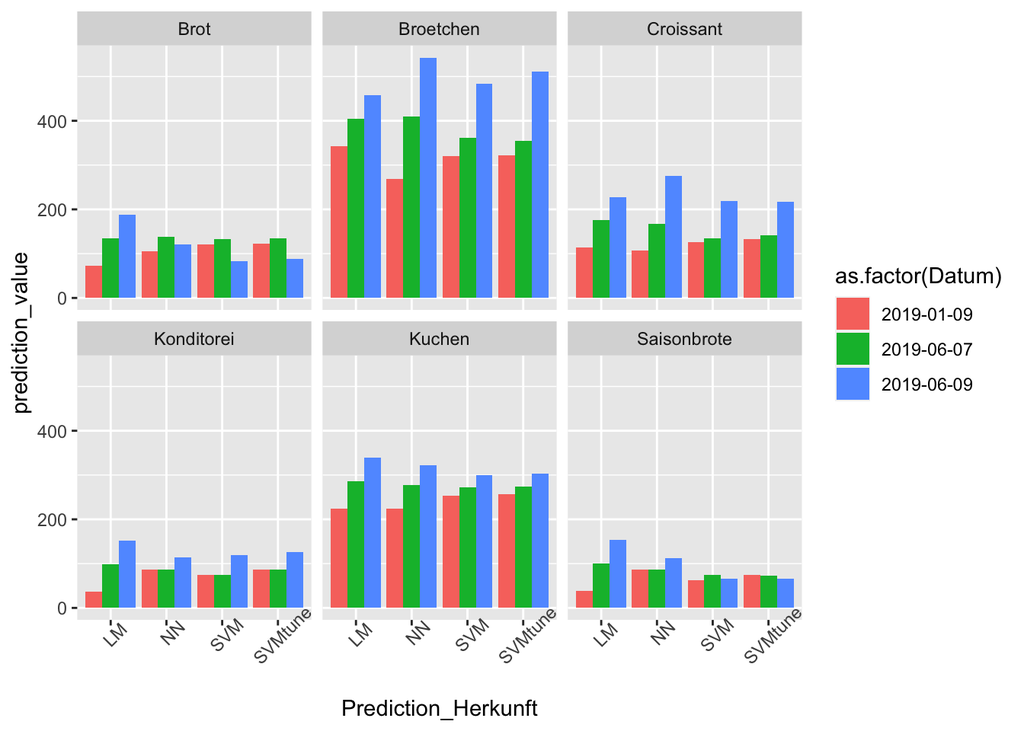

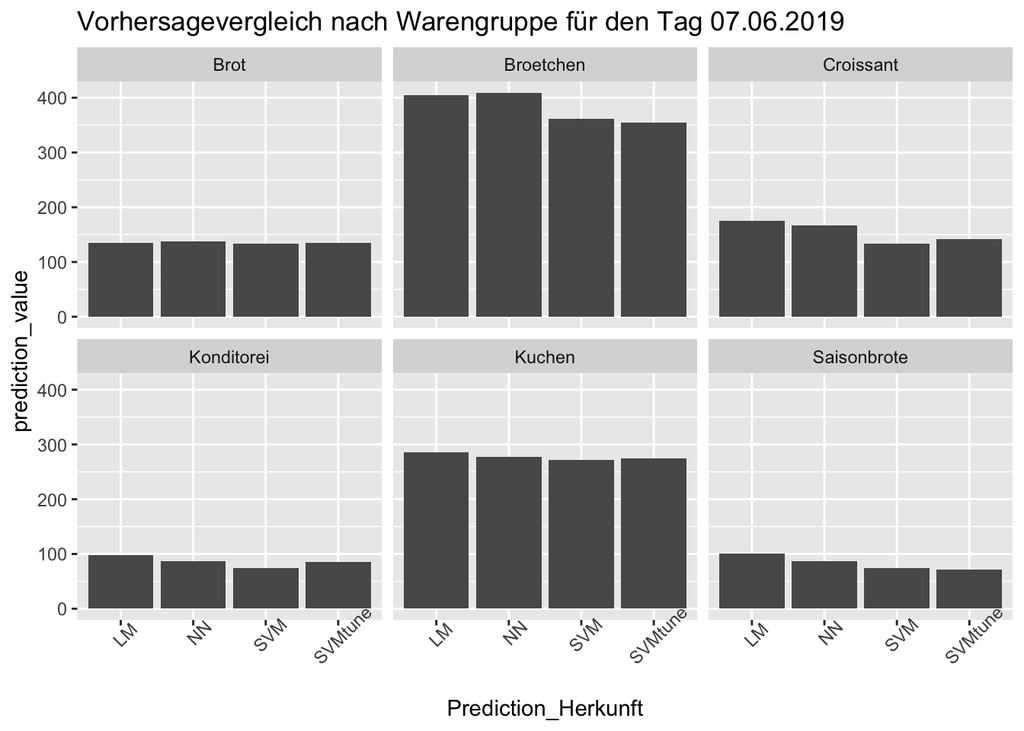